# heat

# SQLite virtual tables in R

We require `dplyr` and `RSQLite` to be able to read our data set.

`magrittr` is for the forward-pipe operator, `%>%`, similar to F#’s `|>`.

`ggplot` provides a plotting tool that integrates really well with `dplyr`, as it provides “graphics transformers”.

This allows you to write programs that are chains in the combinator pattern: input data => transformers => graphics transformers => image

```r
library(RSQLite)
library(dplyr)
```

```r
library(magrittr)
library(ggplot2)
```

The first thing we need to do is setup `dplyr` to work with our virtual table implementation over our scientific data set.

This requires some SQLite code to get things set up. In particular, `select load_extension` allows us to load our virtual table extension for our data format. These are the only lines of SQL that we’ll need.

In our equivalent Python version, `apsw` has a command `.loadextension`, but you can load extensions with `select load_extension` in SQL. This works for the `sqlite3` command line tool that comes with SQLite.

```r
db <- src_memdb()  # this is dplyr code for a new SQLite in memory database
conn <- db $ con
# load virtual table extension for our data
dbGetQuery(conn, "select load_extension('/home/lc17/sqlite/heat.so')")
```

```
##   load_extension('/home/lc17/sqlite/heat.so')
## 1                                          NA
```

```r
# load the data set
dbGetQuery(conn, "create virtual table thrust using heat('/home/lc17/thrust/data')")
```

```
## data frame with 0 columns and 0 rows
```

```r
# just to verify that it's working
dbGetQuery(conn, "select count() from thrust where time = 3000")
```

```
##   count()
## 1   40000
```

Now, we can create a `dplyr` table on the data set from SQLite.

```r
thrust <- tbl(db, "thrust")
thrust
```

```
## Source:   query [?? x 5]
## Database: sqlite 3.16.2 [:memory:]
##
## # A tibble: ?? x 5
##        i     j        heat processor  time
##    <int> <int>       <dbl>     <int> <int>
##  1     1     1 1.11763e-07         0  6400
##  2     2     1 2.23387e-07         0  6400
##  3     3     1 3.34737e-07         0  6400
##  4     4     1 4.45674e-07         0  6400
##  5     5     1 5.56065e-07         0  6400
##  6     6     1 6.65773e-07         0  6400
##  7     7     1 7.74668e-07         0  6400
##  8     8     1 8.82620e-07         0  6400
##  9     9     1 9.89500e-07         0  6400
## 10    10     1 1.09519e-06         0  6400
## # ... with more rows
```

Just so we have them, we can create tables for the other versions of the heat transfer simulation.

```r
dbGetQuery(conn,
  "create virtual table fortran using heat('/home/lc17/fortran/data')")
```

```
## data frame with 0 columns and 0 rows
```

```r
dbGetQuery(conn,
  "create virtual table scala using heat('/home/lc17/scala/data')")
```

```
## data frame with 0 columns and 0 rows
```

```r
dbGetQuery(conn,
  "create virtual table haskell using heat('/home/lc17/haskell/data')")
```

```
## data frame with 0 columns and 0 rows
```

```r
fortran <- tbl(db, "fortran")
scala <- tbl(db, "scala")
haskell <- tbl(db, "haskell")
```

And now, we can start querying.

In `dplyr`, you can think that a `tbl` is a set of named tuples, which are immutable. Every operation is lazily evaluated, such that data is not fetched to R until a “sink” is encountered, like displaying the data.

What this is doing is building up a sequence of SQL commands, which are “views” or nested subqueries over the input data set. There’s very little DSL translation going on between dplyr and SQL – i.e., there’s no magic compiler, because there is such a small distance between SQL and traversable combinators.

We will do a simple query over the Haskell version of the heat simulation, combining a `filter`, `select` (projection, tuple remapping), and `mutate` (map).

For example, with `explain`, R shows us that the `dplyr` code translates into:

```r
explain(haskell %>%
          filter(heat > 0 && time == 0) %>%
          select(-i, -j) %>%
          mutate(plusone=heat+1))
```

```
## <SQL>
## SELECT `heat`, `processor`, `time`, `heat` + 1.0 AS `plusone`
## FROM (SELECT `heat` AS `heat`, `processor` AS `processor`, `time` AS `time`
## FROM (SELECT *
## FROM `haskell`
## WHERE (`heat` > 0.0 AND `time` = 0.0)))
```

```
## <PLAN>
##    addr       opcode p1 p2 p3           p4 p5 comment
## 1     0         Init  0 18  0              00      NA
## 2     1        VOpen  2  0  0 vtab:5830228 00      NA
## 3     2         Real  0  3  0            0 00      NA
## 4     3      Integer  2  1  0              00      NA
## 5     4      Integer  1  2  0              00      NA
## 6     5      VFilter  2 17  1              00      NA
## 7     6      VColumn  2  2  4              00      NA
## 8     7 RealAffinity  4  0  0              00      NA
## 9     8           Le  5 16  4     (BINARY) 55      NA
## 10    9      VColumn  2  4  6              00      NA
## 11   10           Ne  5 16  6     (BINARY) 54      NA
## 12   11         Copy  4  7  0              00      NA
## 13   12      VColumn  2  3  8              00      NA
## 14   13         Copy  6  9  0              00      NA
## 15   14          Add 12  4 10              00      NA
## 16   15    ResultRow  7  4  0              00      NA
## 17   16        VNext  2  6  0              00      NA
## 18   17         Halt  0  0  0              00      NA
## 19   18  Transaction  0  0  4            0 01      NA
## 20   19         Real  0  5  0            0 00      NA
## 21   20         Real  0 12  0            1 00      NA
## 22   21         Goto  0  1  0              00      NA
```

Let’s go on, and do some analysis on our Haskell version of the simulation.

### Analysis of the Haskell version

I’m going to plot the data around one of the initial “hot spots” over time.

First, we’ll get the initial points where the heat starts at one. `collect` copies the data from `SQLite` to `R` (in memory) as a data frame.

```r
points <- haskell %>%
  filter(heat == 1 && time == 0) %>%
  select(ci=i, cj=j) %>%
  collect()
points
```

```
## # A tibble: 4 x 2
##      ci    cj
##   <int> <int>
## 1   110   110
## 2   155    30
## 3   156   153
## 4   157   110
```

We’ll calculate bounds around the 2nd initial point within 10 units in the i, j dimensions.

```r
second <- points %>% filter(ci == 155)
xleft <- second %>% select(ci) %>% collect() %>% .$ci - 10
ybottom <- second %>% select(cj) %>% collect() %>% .$cj - 10
xright <- xleft + 20
ytop <- ybottom + 20
```

And show the result averaging all of the points that are around that center point.

We `filter` the points if they are within the bounds, and then `group_by` time (`group_by` partitions points by attribute values). Then, we average the heat value for all of the points grouped by time – applying a “window” function over the group.

`group_by` can be though of as a sort by key, but then creates sub-sequences based on that key, which then a `map` operation can be applied. It’s sort of the inverse of `flatMap` where `flatMap` goes from a list of lists to a list, [[a]] -> [a]. `group_by` goes from a list to a list of lists, [a] -> [[a]].

```r
result <- haskell %>%
  filter(xleft < i && i < xright) %>%
  filter(ybottom < j && j < ytop) %>%
  group_by(time) %>%
  summarize(heat = avg(heat))
result
```

```
## Source:   query [?? x 2]
## Database: sqlite 3.16.2 [:memory:]
##
## # A tibble: ?? x 2
##     time         heat
##    <int>        <dbl>
##  1     0 0.0027700831
##  2   100 0.0024688977
##  3   200 0.0018730956
##  4   300 0.0014697110
##  5   400 0.0012018578
##  6   500 0.0010143834
##  7   600 0.0008766467
##  8   700 0.0007714130
##  9   800 0.0006884434
## 10   900 0.0006213261
## # ... with more rows
```

With the data in hand, we can pipe it directly to the graphics transformers found in `ggplot`. Though, as we noted before, actually `result` is not computed immediately. `result` is sitting there waiting to be executed, because it is lazily evaluated. So, we have to `collect` it to R, so that `ggplot` is able to transform the data to graphics. `ggplot` will sort x and y by x for us.

One thing `dplyr` does not have, unlike Spark, is that it does not “implicitly” cache the results – but `dplyr` can directly work with Spark via `sparklyr`. Thus, with a SQLite Virtual Table, you can query data directly, and then if you need to, load it directly in Spark, all through `dplyr`.

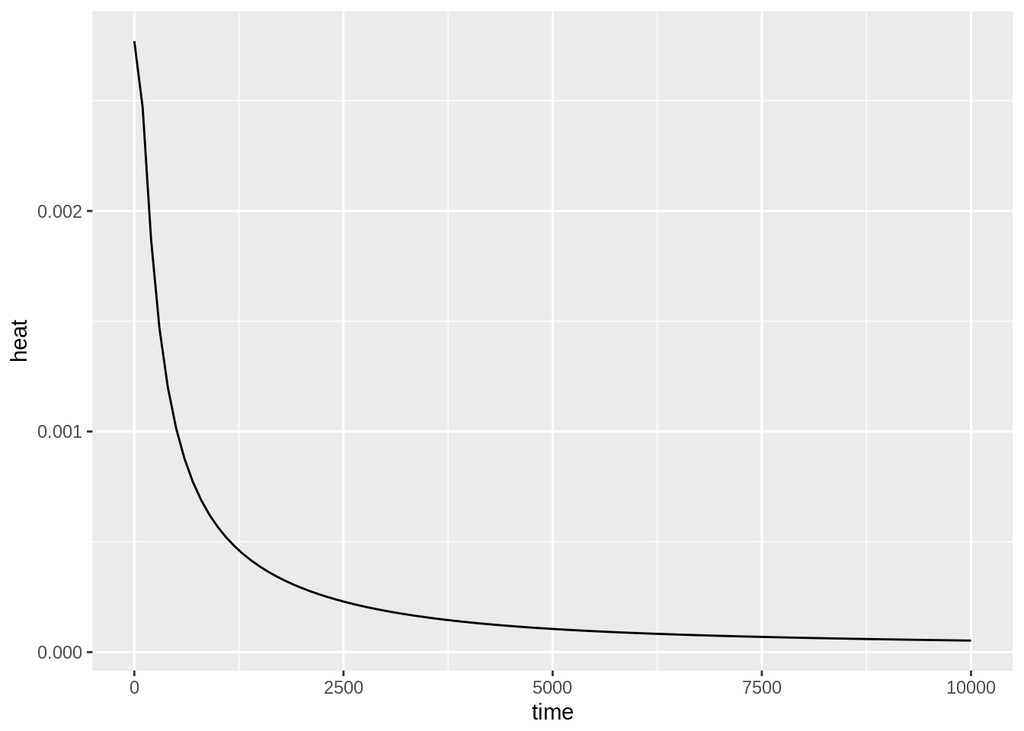

```r
result %>%
  # move data to R
  collect() %>%
  # turn into graphics
  ggplot() +
  # describe "aethetics", i.e., data to graphics mappings
  aes(x=time, y=heat) +
  # transform data into graphic primitives
  geom_line()
```

Let’s now do it for all of the initial points.

This time, we’ll create a query that is the initial points but with “bounding boxes”" around each initial point.

```r
boxes <- points %>%
  mutate(cleft=ci-10, cright=ci+10, cbottom=cj-10, ctop=cj+10) %>%
  select(-ci, -cj) %>%
  mutate(id=row_number())
boxes
```

```
## # A tibble: 4 x 5
##   cleft cright cbottom  ctop    id
##   <dbl>  <dbl>   <dbl> <dbl> <int>
## 1   100    120     100   120     1
## 2   145    165      20    40     2
## 3   146    166     143   163     3
## 4   147    167     100   120     4
```

With the bounding boxes, we will do a Cartesian product, aka cross join, between the bounds and each point, such that they are all annotated with the bounds that we care about.

To do an cross join in dplyr though, we have to cheat with an inner join /equijoin, by adding a constant value to each, and then joining on the constant value.

Then, we do the same as before, filter out the points if they are only within the boundaries of some distance to the initial heat points.

### Thinking with data parallelism

Up to this point, I haven’t talked about “data parallelism”. Data parallelism is SIMD, or “Single Instruction Multiple Data”, or SPMD, “Single Program Multiple Data”. One of the great things about the relational data model and the traversable model, is that if you restrict yourself to the primitives, the execution is automatically parallelizable.

Nowadays, people would call this the “map-reduce” paradigm. Spark is a great example of this, and how to parallelize computations if you stick to the primitives. GPU and graphics programming is another example of data parallel programming. The relational data model is data parallel, too, if we avoid the mutables, i.e., INSERT, DELETE, and UPDATE.

To begin “thinking with parallelism”, this example illustrates how do we avoid using nested loops and ifs, the bane of parallelism, and think in terms of joins and filters.

Think how you might implement the filtering in an imperative way:

```
for all points
  for all center points
    if within some distance to a center
      retain point
```

If we do this in a psuedo-list comprehension: it might be `[filter-center x | x <- xs]`, where `filter-center` is some closure over the center points. But that `filter-center` might have a loop itself (traverse or map), which is “nested parallelism” – we will be avoiding any nested parallelism, because it does not fit with the relational model or the flattened data parallel model.

Thus, we will be flattening all doubly nested for loops, and won’t be creating closures. In our filter example, we annotated each tuple (row) with the tuple that we want to compare to, the bounds around the center points through the Cartesian product, and filter on that one list.

That is, nested iteration, or doubly nested for loops are forbidden in a relational or data parallel model. In particular, a nested for-loop implies a closure (current name binding of values, i.e., current program executation state or the state of the program stack) of the current state in the outer for loop. Creating closures are fine when we have single-threaded systems, but not so in parallel systems due to the overhead of copying closures around.

Though, I’m lying a little when I say we are avoiding doubly nested for loops, rather we are using join to implement them. In the end, a double iteration has to occur, but the value of the two lists is known at the time of the join. Whereas, if we did this with an inner iteration, that inner iteration might be dependent on some values on the outer iteration, creating closures, which are hard to parallelize. By using a join, we are removing any data dependencies on the inner loop, because the only thing that a join takes is the two tables and the functor for evaluating the join.

In particular, if you have programmed in Spark, think about the problems that you run into whenever you create a closure that isn’t binding static values… This is that exact issue.

```r
boxes <- boxes %>% mutate(dummy=1)
areas <- haskell %>%
  # cross join aka Cartesian product
  # we have to do a small hack, because dplyr doesn't
  # support cross join currently
  mutate(dummy=1) %>%
  inner_join(boxes, copy=TRUE) %>%
  select(-dummy) %>%
  # filter out all points that are not in the bounds
  filter(cleft <= i && i <= cright && cbottom <= j && j <= ctop) %>%
  select(-cleft, -cright, -cbottom, -ctop) %>%
  # group by both time and id
  group_by(time, id) %>%
  # average heat within bounds
  summarize(heat = avg(heat))
areas
```

```
## Source:   query [?? x 3]
## Database: sqlite 3.16.2 [:memory:]
## Groups: time
##
## # A tibble: ?? x 3
##     time    id        heat
##    <int> <int>       <dbl>
##  1     0     1 0.002267574
##  2     0     2 0.002267574
##  3     0     3 0.002267574
##  4     0     4 0.002267574
##  5   100     1 0.002113101
##  6   100     2 0.002113101
##  7   100     3 0.002113101
##  8   100     4 0.002113101
##  9   200     1 0.001691562
## 10   200     2 0.001691562
## # ... with more rows
```

And then plot. We pass the `id` column to `ggplot` to be able to plot multiple lines, and again we don’t need to sort x or y by x because it does it for us.

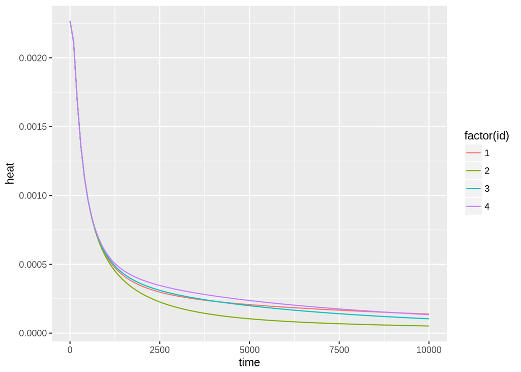

```r
areas %>%
  collect() %>%
  ggplot() +
  aes(x=time, y=heat, group=id, color=factor(id)) +
  geom_line()
```

### Manually creating a histogram

Next, we’ll create a histogram of temperature values over the entire time seuqnce from scratch. While it is possible just to pass data to `ggplot` that you want to histogram, it’s informative how to do it yourself, especially in a relational or data parallel way.

First, we’ll create a table that has some data values that we need to be able to scale our data into histogram bins, i.e., a bias and scale.

```r
min_heat <- thrust %>%
  filter(heat > 0) %>%
  # figure out min heat > 0
  summarize(bias=log10(min(heat))) %>%
  # create values to be able to bin into 256
  mutate(scale=255.0/(0 - bias)) %>%
  select(bias, scale) %>%
  # compute cache the result into a temporary table
  # it's basically "force"
  compute()
min_heat
```

```
## Source:   query [?? x 2]
## Database: sqlite 3.16.2 [:memory:]
##
## # A tibble: ?? x 2
##      bias    scale
##     <dbl>    <dbl>
## 1 -90.309 2.823639
```

Again, we’ll do the same trick as before, to do a “fake” cross join, to attach our data to each row. First, we’ll set all the zeros to the min value, because we want to do a log scale.

```r
min_heat <- min_heat %>% mutate(dummy=1)
zeros <- thrust %>%
  # only values = 0
  filter(heat == 0.0) %>%
  mutate(dummy=1) %>%
  # attach our bias and scale
  inner_join(min_heat) %>%
  # if zero, set to min_heat
  mutate(heat = bias, dummy=1) %>%
  select(heat, bias, scale)
zeros
```

```
## Source:   query [?? x 3]
## Database: sqlite 3.16.2 [:memory:]
##
## # A tibble: ?? x 3
##       heat    bias    scale
##      <dbl>   <dbl>    <dbl>
##  1 -90.309 -90.309 2.823639
##  2 -90.309 -90.309 2.823639
##  3 -90.309 -90.309 2.823639
##  4 -90.309 -90.309 2.823639
##  5 -90.309 -90.309 2.823639
##  6 -90.309 -90.309 2.823639
##  7 -90.309 -90.309 2.823639
##  8 -90.309 -90.309 2.823639
##  9 -90.309 -90.309 2.823639
## 10 -90.309 -90.309 2.823639
## # ... with more rows
```

Next, we’ll do the same for all the rest of the values, attach the bias and scale, but also union in the zeros. Then, we discrete everything using our bias and scale values.

Then, we actually do the histogram by counting the number of values in a bin.

```r
rest <- thrust %>%
  # if > 0
  filter(heat > 0.0) %>%
  # convert to log scale
  mutate(heat = log10(heat)) %>%
  mutate(dummy=1) %>%
  # attach our bias and scale
  inner_join(min_heat) %>%
  # add in the zeros
  select(heat, bias, scale) %>%
  union_all(zeros) %>%
  # discretize them into bins
  mutate(bin = round(scale * (heat - bias), 0)) %>%
  # actually do the histogram
  # group by bin
  group_by(bin) %>%
  # bin count
  summarize(freq = n()) %>%
  # scale the bin counts by log10
  mutate(freq = log10(freq)) %>%
  select(bin, freq)
rest
```

```
## Source:   query [?? x 2]
## Database: sqlite 3.16.2 [:memory:]
##
## # A tibble: ?? x 2
##      bin      freq
##    <dbl>     <dbl>
##  1     0 4.6676957
##  2     6 0.6020600
##  3     7 0.3010300
##  4    10 0.6020600
##  5    13 0.6020600
##  6    14 0.3010300
##  7    15 0.6020600
##  8    18 0.6020600
##  9    19 0.4771213
## 10    20 0.7781513
## # ... with more rows
```

Though, notice we have “missing” values, we can add in a bunch of zeros. I’m going to “cheat” a little here and create a data frame with the zeros and copy that over the SQLite.

```r
empty <- copy_to(db, data.frame(bin=0:256, freq=0.0), "empty")
empty
```

```
## Source:   query [?? x 2]
## Database: sqlite 3.16.2 [:memory:]
##
## # A tibble: ?? x 2
##      bin  freq
##    <int> <dbl>
##  1     0     0
##  2     1     0
##  3     2     0
##  4     3     0
##  5     4     0
##  6     5     0
##  7     6     0
##  8     7     0
##  9     8     0
## 10     9     0
## # ... with more rows
```

Then, we take the union of these zeros with the rest of the data and then sum the 0s with the other bin values.

Finally, we plot.

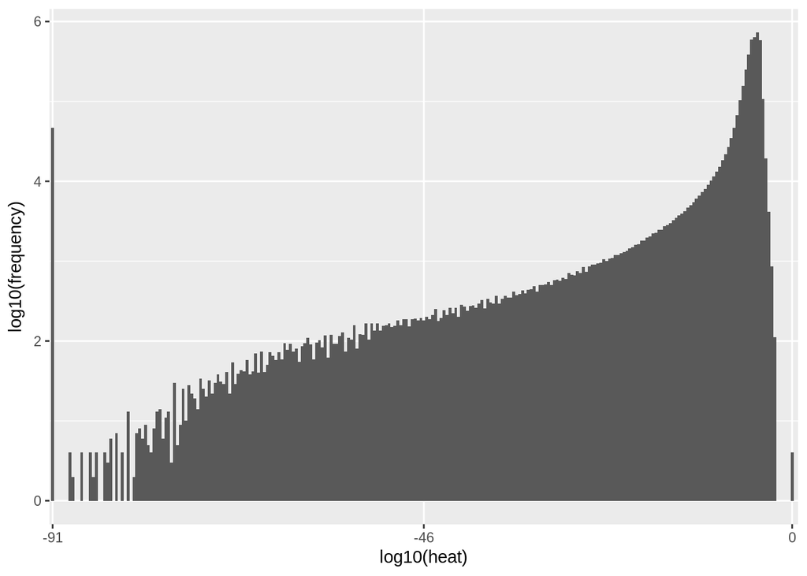

```r
# union the zeros with our calculated data
bias <- collect(min_heat) %>% .[[1]]
empty %>%
  union(rest) %>%
  # sum up the bins with the zeros
  group_by(bin) %>%
  summarize(freq=sum(freq)) %>%
  # send to R
  collect() %>%
  ggplot() +
  # create column/bar plot by bin and frequency
  aes(x=bin, y=freq) +
  geom_col(width=1) +
  # add our labels
  xlab("log10(heat)") +
  ylab("log10(frequency)") +
  # and adjust the axis labels
  scale_x_discrete(limits=c(0, 128, 255),
                   labels=c(floor(bias), floor(bias*.5), 0))
```